# Deep Learning in Unsupervised Learning

## Autoencoders

### Introduction

- Autoencoders are a type of artificial neural network used for unsupervised learning of efficient codings, with applications in dimensionality reduction, feature learning, and more recently, generative models.
- The main goal of an autoencoder is **to learn a representation (encoding) for a set of data**, typically for the purpose of dimensionality reduction, by training the network to ignore signal “noise.”

### Structure of Autoencoders

An autoencoder consists of tree main parts: the encoder, the latent space and the decoder.

- **Encoder**: This part of the network compresses the input into a latent-space representation. It encapsulates the inputs into a lower-dimensional code. This process reduces the dimensionality of the data by learning how to ignore non relevant features in the input.
- **Latent vector**: This is also referred to as latent representation or latent space in some literature. This represents the most important features of the input data in a lower-dimensional form. This is the output provided by the encoder and will be the input for the decoder. The dimension of the latent vector can be bigger than $x$. If so, the autoencoder will simply copy the input to the output. In other words, it will try to memorize the input data. However, in most cases, the dimension of the latent vector is much smaller than $x$.
- **Decoder**: After encoding, the decoder part of the network reconstructs the input data from the encoded representation. The aim is to produce an output that matches the input as closely as possible, essentially learning the identity function under certain constraints.

[figure not shown]

*An autoencoder consists of 3 components: encoder, code and decoder. The encoder compresses the input and produces the code, the decoder then reconstructs the input only using this code.*

- First the input passes through the encoder, which is a fully-connected ANN, to produce the code. The decoder, which has the similar NN structure, then produces the output only using the code.
- The goal is to get an **output identical with the input**.
- Note that the decoder architecture is the mirror image of the encoder. This is not a requirement but it’s typically the case. The only requirement is the dimensionality of the input and output needs to be the same. Anything in the middle can be played with.

[figure not shown]

*In the simpler version, both the encoder and decoder are fully-connected feedforward neural networks (but we can have more complicated architecture for example CNN). Code is a single layer of an ANN with the dimensionality of our choice. The number of nodes in the code layer (code size) is a hyperparameter that we set before training the autoencoder.*

- From a more formal point of view, The encoder network receives a $d$-dimensional input feature vector associated with example $x$ (that is, $𝒙 \in \mathbb{R}^d$) and encodes it into a $p$-dimensional vector, $z$ (that is, $𝒛 \in \mathbb{R}^p$ ).
- In other words, the role of the encoder is to learn how to model the function $𝒛 =f(x)$ .
- The encoded vector, $z$, is also called the latent vector, or the latent feature representation.
- Typically, the dimensionality of the latent vector is less than that of the input examples; in other words, $p < d$. Hence, we can say that the encoder acts as a data compression function.
- Then, the decoder decompresses $\hat x$ from the lower-dimensional latent vector, $z$, where we can think of the decoder as a function, $\hat x = g(z)$.

### Variants of Autoencoders

Autoencoders can be categorized into several types, each with unique characteristics and applications:

- **Basic Autoencoders**: Focus on encoding and decoding input data to learn efficient data codings.
- **Sparse Autoencoders**: Introduce sparsity in the encoded representations to improve robustness and achieve better feature selection.
- **Denoising Autoencoders**: Aim to reconstruct the input from a corrupted version, thus learning to ignore or “denoise” the input.
- **Convolutional Autoencoders**: Utilize convolutional neural networks (CNNs) in the encoder and decoder, making them suitable for image data.
- **Variational Autoencoders (VAEs)**: Incorporate probabilistic layers to model the input distribution, enabling them to generate new data that's similar to the input data.

### Training Autoencoders

- Training an autoencoder involves using backpropagation, just as with other types of neural networks.
- However, instead of predicting a target value, autoencoders aim to reproduce their inputs.
- Therefore, the loss function used during training measures the difference between the input and the output (reconstruction loss), such as the mean squared error for continuous input data or cross-entropy for binary input data.

[figure not shown]

### Applications of Autoencoders

Autoencoders have a wide range of applications:

- **Dimensionality Reduction**: Similar to PCA but more powerful due to their non-linearity, autoencoders can reduce the dimensionality of data for visualization or preprocessing steps.
- **Feature Learning**: They can learn features from raw data that can be useful for classification tasks or other machine learning applications.
- **Denoising**: Autoencoders can remove noise from data, which is valuable for tasks like image denoising or signal processing.
- **Anomaly Detection**: By learning to reproduce normal data, autoencoders can be used to detect outliers or anomalies in datasets.
- **Generative Models**: Variational autoencoders and their extensions can generate new data that's similar to the training data, useful in domains like drug discovery or creative art generation.

### A simple example

We will use the extremely popular [MNIST](https://en.wikipedia.org/wiki/MNIST_database) dataset as input. It contains black-and-white images of handwritten digits.

[figure not shown]

They’re of size 28x28 and we use them as a vector of 784 numbers between [0, 1]. We will now implement the autoencoder with Keras. The hyperparameters are: 128 nodes in the hidden layer, code size is 32, and binary crossentropy is the loss function.

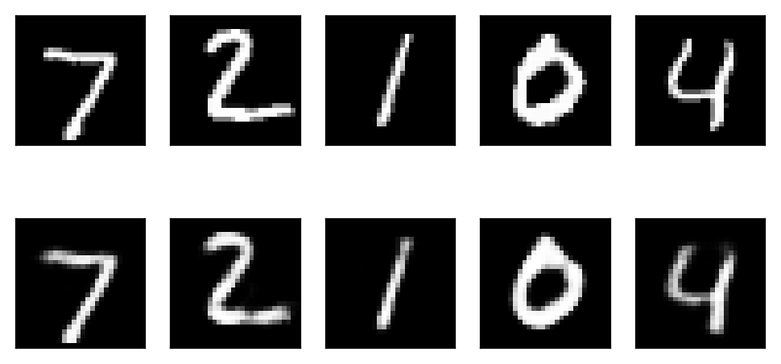

**A word of caution**

- We possess full control over the design of the autoencoder, enabling us to enhance its capabilities by adding more layers, increasing the number of nodes in each layer, and, most crucially, expanding the code size. By adjusting these hyperparameters, the autoencoder can capture more complex patterns.
- However, caution is needed to avoid making it excessively powerful, as it may end up merely duplicating its inputs to the outputs without capturing any significant representations, effectively acting as the identity function. In such cases, the autoencoder would perfectly reconstruct the training data but fail to generalize to new data due to overfitting, which is undesirable.

### Denoising Autoencoder

Keeping the code layer small forced our autoencoder to learn an intelligent representation of the data. There is another way to force the autoencoder to learn useful features, which is adding random noise to its inputs and making it recover the original noise-free data. This way the autoencoder can’t simply copy the input to its output because the input also contains random noise. We are asking it to subtract the noise and produce the underlying meaningful data. This is called a denoising autoencoder.

[figure not shown]

*We add random Gaussian noise to them and the noisy data becomes the input to the autoencoder. The autoencoder doesn’t see the original image at all. But then we expect the autoencoder to regenerate the noise-free original image.*

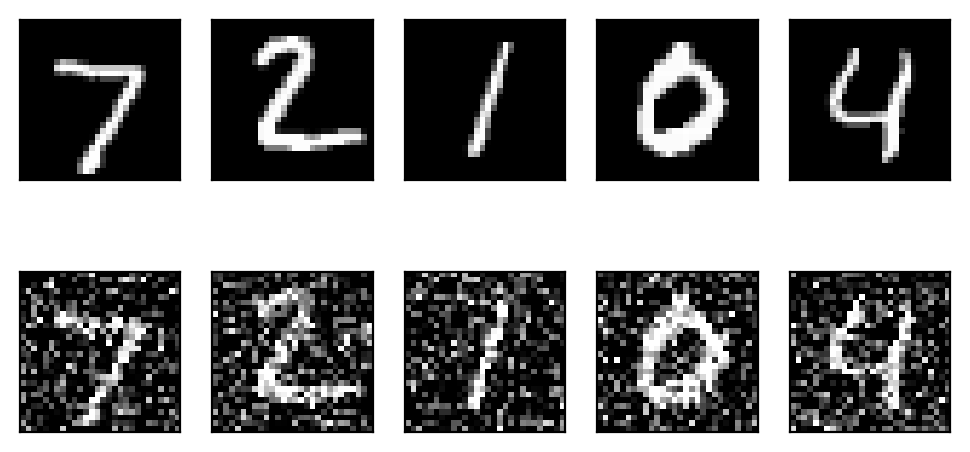

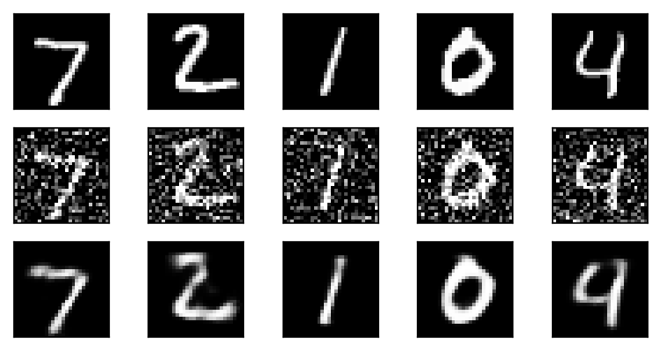

### Sparse Autoencoders

- We introduced two ways to force the autoencoder to learn useful features: keeping the code size small and denoising autoencoders.
- The third method is using regularization. We can regularize the autoencoder by using a sparsity constraint such that only a fraction of the nodes would have nonzero values, called active nodes.
- In particular, we add a penalty term to the loss function such that only a fraction of the nodes become active. This forces the autoencoder to represent each input as a combination of small number of nodes, and demands it to discover interesting structure in the data. This method works even if the code size is large, since only a small subset of the nodes will be active at any time. It’s pretty easy to do this in Keras with just one parameter

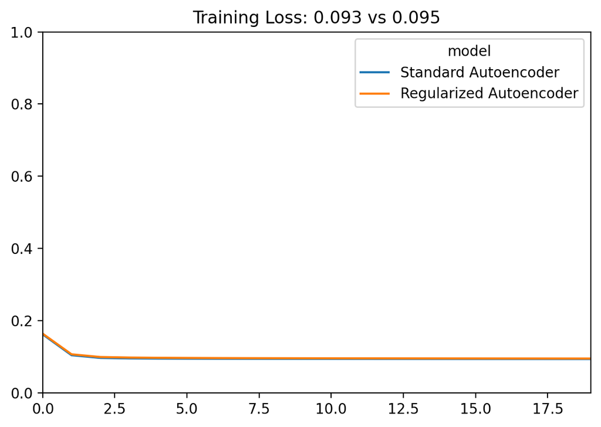

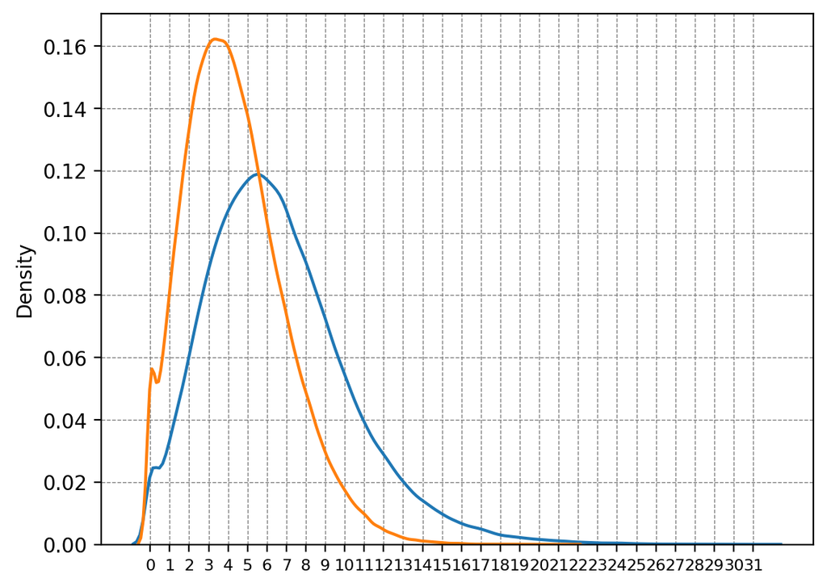

## References and Credits

[1] - Dertat A. - ["Applied Deep Learning - Part 3: Autoencoders"](https://towardsdatascience.com/applied-deep-learning-part-3-autoencoders-1c083af4d798), Published in Towards Data Science